# STAT571 HW1 Group 18 - Case 3

# Case 3: MLB

## Setup & Imports

```r
knitr::opts_chunk$set(fig.width=10, fig.height=6) # do figure formatting for eventual knitted output
if(!require('pacman')) {install.packages('pacman')} # if you don't have pacman, install it
pacman::p_load(ISLR, readxl, tidyverse, magrittr, dplyr, ggplot2) # load necessary packages
```

## Read in Data

```r
baseball <- read.csv(file = 'data/baseball.csv') # read in the long-format csv as a data.frame
head(baseball, 5) # display the first 5 rows
```

|  | team | year | payroll | win_num | win_pct |
| --- | --- | --- | --- | --- | --- |
| 1 | Arizona Diamondbacks | 1998 | 31.61450 | 65 | 0.4012346 |
| 2 | Arizona Diamondbacks | 1999 | 70.49600 | 100 | 0.6172840 |
| 3 | Arizona Diamondbacks | 2000 | 81.02783 | 85 | 0.5246914 |
| 4 | Arizona Diamondbacks | 2001 | 81.20651 | 92 | 0.5679012 |
| 5 | Arizona Diamondbacks | 2002 | 102.82000 | 98 | 0.6049383 |

## 4.1 EDA: Relationship between payroll changes and performance

First, we create a new variable called diff_lag, which describes the log difference between a year’s payroll and the previous years’ payroll.

In this setup, it is more appropriate to work with log-transformed data because it is more informative about *relative* differences than the raw amount of payroll increase. In other words, the same amount of raw change in payroll would represent a more significant increase to a team earning less, than a team earning more, so we can take the differences of the log values to address this.

```r
baseball$diff_log <-  log(baseball$payroll) - log(lag(baseball$payroll)) # here we create the new variable of differences of log values
baseball$diff_win_pct <-  baseball$win_pct - lag(baseball$win_pct) # I'm also going to create a variable that describes the change in win_pct, which will be useful in 4.2 and later sections

# now, we create a new table with our variables of interest
baseball_variables <- baseball %>%
  select(team, year, diff_log, payroll, win_pct, diff_win_pct) %>%
  na.omit # Because the first year in our data will not have a computable change from the previous year, it will produce an NA in the diff_log column. This particular row will not contain information relevant to our analysis, so we can simply omit the rows that have NAs.

head(baseball_variables, 5) # let's take a look to make sure we've got what we need
```

|  | team | year | diff_log | payroll | win_pct | diff_win_pct |
| --- | --- | --- | --- | --- | --- | --- |
| 2 | Arizona Diamondbacks | 1999 | 0.80194009 | 70.49600 | 0.6172840 | 0.21604938 |
| 3 | Arizona Diamondbacks | 2000 | 0.13923674 | 81.02783 | 0.5246914 | -0.09259259 |
| 4 | Arizona Diamondbacks | 2001 | 0.00220274 | 81.20651 | 0.5679012 | 0.04320988 |
| 5 | Arizona Diamondbacks | 2002 | 0.23598443 | 102.82000 | 0.6049383 | 0.03703704 |
| 6 | Arizona Diamondbacks | 2003 | -0.24298095 | 80.64033 | 0.5185185 | -0.08641975 |

## 4.2 Exploratory questions

```r
# to answer these questions, let's create a new data.frame that contains each team, their corresponding log chang ein payroll between 2010 and 2014, and their corresponding change in win percentage between those same years
baseball_variables_2010_2014 <- data.frame(unique(baseball_variables$team),
                                           log(baseball_variables$payroll[baseball_variables$year == 2014]) - log(baseball_variables$payroll[baseball_variables$year == 2010]),
                                           baseball_variables$win_pct[baseball_variables$year == 2014] - baseball_variables$win_pct[baseball_variables$year == 2010])
colnames(baseball_variables_2010_2014) <- c('team', 'diff_log_2014_2010', 'diff_win_pct_2014_2010') # appropriately name the columns

# now, let's see which 5 teams had the largest increase in payroll between 2010 and 2014
baseball_variables_2010_2014 %>%
  arrange(desc(diff_log_2014_2010)) %>% # order rows by descending log pay change
  head(5) # show the top 5
```

|  | team | diff_log_2014_2010 | diff_win_pct_2014_2010 |
| --- | --- | --- | --- |
| 1 | Los Angeles Dodgers | 0.9075378 | 0.08641975 |
| 2 | Texas Rangers | 0.9010426 | -0.14197531 |
| 3 | San Diego Padres | 0.8685652 | -0.08024691 |
| 4 | Pittsburgh Pirates | 0.8044213 | 0.19135802 |
| 5 | Washington Nationals | 0.7852661 | 0.16666667 |

```r
# which 5 teams had the largest increase in win percentage between 2010 and 2014?
baseball_variables_2010_2014 %>%
  arrange(desc(diff_win_pct_2014_2010)) %>% # order rows by descending win_pct change
  head(5) # show the top 5
```

|  | team | diff_log_2014_2010 | diff_win_pct_2014_2010 |
| --- | --- | --- | --- |
| 1 | Pittsburgh Pirates | 0.80442127 | 0.1913580 |
| 2 | Baltimore Orioles | 0.27463941 | 0.1851852 |
| 3 | Washington Nationals | 0.78526610 | 0.1666667 |
| 4 | Seattle Mariners | -0.06612479 | 0.1604938 |
| 5 | Kansas City Royals | 0.24178440 | 0.1358025 |

As we can see, the top 5 teams with the highest log payroll increase between 2010 and 2014 are:

1. Los Angeles Dodgers
2. Texas Rangers
3. San Diego Padres
4. Pittsburgh Pirates
5. Washington Nationals

And the top 5 teams with the highest win percentage increase between 2010 and 2014 are:

1. Pittsburgh Pirates
2. Baltimore Orioles
3. Washington Nationals
4. Seattle Mariners
5. Kansas City Royals

## 4.3 Do log increases in payroll imply better performance?

```r
# run a linear model to evaluate the regression of diff_log on change in win percentage
baseball_model <- lm(diff_win_pct ~ diff_log, data = baseball_variables)
summary(baseball_model) # lm output
```

```
Call:
lm(formula = diff_win_pct ~ diff_log, data = baseball_variables)

Residuals:
     Min       1Q   Median       3Q      Max
-0.20317 -0.04727 -0.00255  0.04569  0.26860

Coefficients:
             Estimate Std. Error t value Pr(>|t|)
(Intercept) 0.0003302  0.0031683   0.104   0.9170
diff_log    0.0160637  0.0079063   2.032   0.0427 *
---
Signif. codes:  0 ‘***’ 0.001 ‘**’ 0.01 ‘*’ 0.05 ‘.’ 0.1 ‘ ’ 1

Residual standard error: 0.07148 on 507 degrees of freedom
Multiple R-squared:  0.008076,  Adjusted R-squared:  0.00612
F-statistic: 4.128 on 1 and 507 DF,  p-value: 0.0427
```

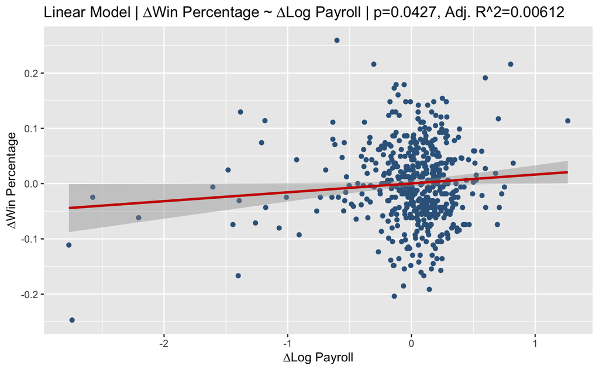

```r
# ok, let's plot the lm
ggplot(baseball_variables, aes(x = diff_log, y = diff_win_pct)) + geom_point(col = "steelblue4") + stat_smooth(method = "lm", col = "red3") + ggtitle("Linear Model | ∆Win Percentage ~ ∆Log Payroll | p=0.0427, Adj. R^2=0.00612") + xlab("∆Log Payroll") + ylab("∆Win Percentage")
```

To test this I have run a linear regression analysis, testing how well change in log payroll predicts change in win percentage. I am using change in win percentage as my dependent variable as opposed to win percentage as such because this provides a picture of how performance responds to our putative predictor of interest.

It appears based on this analysis that while there does seem to be a statistically significant association between log increase in pay and increase in performance (p = 0.043), the effect size is small (Adj. R-Squared = 0.00612). Accordingly, at this stage my interpretation is that while there is in fact evidence that an increase in payroll may lead to an increase in performance, it is likely that change in payroll alone does not adequately explain performance, or that this is only true for some teams, and these specific teams are driving the result.

We have established that aggregating across all teams, there is a small predictive relationship between change in log payroll and change in performance. However, we can dive deeper and see if this is true for all teams, or just a subset of teams. It is possible that for some teams there is a stronger predictive relationship than others. To test this, I will conduct a regression for each team, evaluating the change in log payroll as a predictor of change in performance.

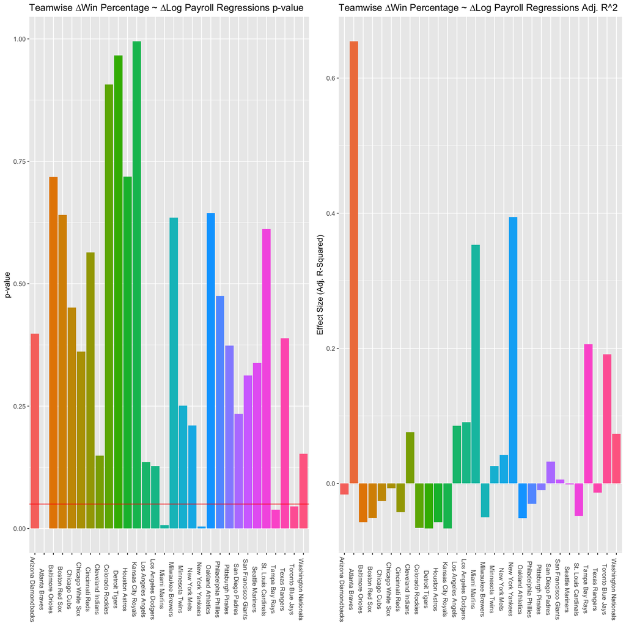

```r
# since we'll be running many linear regressions (one for each team), it's best to initialize empty arrays to contain p-value and effect size (adj. R^2) of each regression
p_vector <- rep(NA, length(unique(baseball_variables$team))) # initialize p-value vector
effect_vector <- rep(NA, length(unique(baseball_variables$team))) # initialize effect size vector
# this loop runs a regression on each team - every iteration corresponds to a single team
for (i in 1:length(unique(baseball_variables$team))){
  temporary_model <- lm(diff_win_pct ~ diff_log, data = baseball_variables %>% filter(team == unique(baseball_variables$team)[i])) # run the regression, select only the rows that pertain to the team of interest
  p_vector[i] <- summary(temporary_model)$coefficients["diff_log",4] # extract the p-value
  effect_vector[i] <- summary(temporary_model)$adj.r.squared # extract the adjusted R^2
}

# great! now let's create a data.frame that contains p-value, effect size, and team
teamwise_regression_result <- data.frame(team = unique(baseball_variables$team), p_value = p_vector, effect_size = effect_vector)

# visualize results
# create a bar plot showing each team's p-value in their regression
p_plot <- ggplot(data=teamwise_regression_result, aes(x=team,y=p_value, fill=team)) + geom_bar(stat='identity') +
  theme(axis.text.x = element_text(angle = -90)) +
  geom_hline(yintercept = 0.05, color = 'red') +
  ggtitle("Teamwise ∆Win Percentage ~ ∆Log Payroll Regressions p-value") + theme(legend.position = "none", axis.title.x=element_blank()) + ylab("p-value")
# create a bar plot showing each team's adjusted r-squared value in their regression
rsq_plot <- ggplot(data=teamwise_regression_result, aes(x=team,y=effect_size, fill=team)) + geom_bar(stat='identity') +
  theme(axis.text.x = element_text(angle = -90)) +
  ggtitle("Teamwise ∆Win Percentage ~ ∆Log Payroll Regressions Adj. R^2") + theme(legend.position = "none", axis.title.x=element_blank()) + ylab("Effect Size (Adj. R-Squared)")
gridExtra::grid.arrange(p_plot, rsq_plot, nrow=1) # plot these together
```

From these results, we can thus infer than this predictive relationship between change in log payroll and change in win percentage is only present in a handful of teams. Specifically, the following teams, whose corresponding regressions resulted in a p-value less than 0.05, with substantial Adj. R^2 values:

1. Atlanta Braves
2. Miami Marlins
3. New York Yankees
4. Tampa Bay Rays
5. Toronto Blue Jays

The result of the earlier regression (across all teams) is likely driven by these 5 teams.

So, in summary, we can conclude the following: While at the aggregate level, there is evidence that an increase in log payroll may lead to an increase in win percentage, the win percentage of the five teams listed above exhibit a robust response to change in log payroll, while other teams do not.

## 4.4 Comparison

In order to make this comparison, we will compare the regressions we ran to test the change in log pay’s predictive ability among individual teams, with regressions testing the predictive ability of payroll as such in predicting change in win percentage, as well as both payroll and change in log payroll’s ability to individually predict overall win percentage This will allow us to see if one variable better explains performance as such, change in performance, or both. In all, we will compare 4 analytic setups.

The criteria we will use is the effect size (R^2) and statistical significance (p-value) of the regression of each independent variable (payroll vs change in log payroll) on change in win percentage. We will compare how many teams achieve statistical significance and a robust effect size in each analysis.

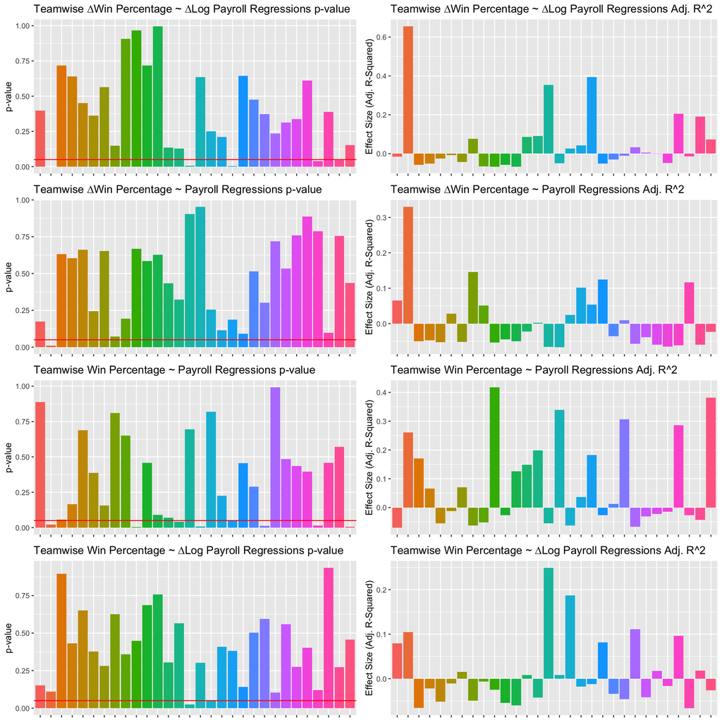

```r
# ----------------- #
#    Analysis 2     #
# ----------------- #

# Let's run the analysis using Payroll to predict change in win percentage
p_vector_2 <- rep(NA, length(unique(baseball_variables$team))) # initialize p-value vector
effect_vector_2 <- rep(NA, length(unique(baseball_variables$team))) # initialize effect size vector
# this loop runs a regression on each team - every iteration corresponds to a single team
for (i in 1:length(unique(baseball_variables$team))){
  temporary_model <- lm(diff_win_pct ~ payroll, data = baseball_variables %>% filter(team == unique(baseball_variables$team)[i])) # run the regression, select only the rows that pertain to the team of interest
  p_vector_2[i] <- summary(temporary_model)$coefficients["payroll",4] # extract the p-value
  effect_vector_2[i] <- summary(temporary_model)$adj.r.squared # extract the adjusted R^2
}
# great! now let's create a data.frame that contains p-value, effect size, and team
teamwise_regression_result_2 <- data.frame(team = unique(baseball_variables$team), p_value = p_vector_2, effect_size = effect_vector_2)
# Save plots
# create a bar plot showing each team's p-value in their regression
p_plot_2 <- ggplot(data=teamwise_regression_result_2, aes(x=team,y=p_value, fill=team)) + geom_bar(stat='identity') +
  theme(axis.text.x = element_text(angle = -90)) +
  geom_hline(yintercept = 0.05, color = 'red') +
  ggtitle("Teamwise ∆Win Percentage ~ Payroll Regressions p-value") + theme(legend.position = "none", axis.title.x=element_blank(), axis.text.x=element_blank()) + ylab("p-value")
# create a bar plot showing each team's adjusted r-squared value in their regression
rsq_plot_2 <- ggplot(data=teamwise_regression_result_2, aes(x=team,y=effect_size, fill=team)) + geom_bar(stat='identity') +
  theme(axis.text.x = element_text(angle = -90)) +
  ggtitle("Teamwise ∆Win Percentage ~ Payroll Regressions Adj. R^2") + theme(legend.position = "none", axis.title.x=element_blank(), axis.text.x=element_blank()) + ylab("Effect Size (Adj. R-Squared)")

# ----------------- #
#    Analysis 3     #
# ----------------- #

# now, let's run the analysis using Payroll to predict Win Percentage
p_vector_3 <- rep(NA, length(unique(baseball_variables$team))) # initialize p-value vector
effect_vector_3 <- rep(NA, length(unique(baseball_variables$team))) # initialize effect size vector
# this loop runs a regression on each team - every iteration corresponds to a single team
for (i in 1:length(unique(baseball_variables$team))){
  temporary_model <- lm(win_pct ~ payroll, data = baseball_variables %>% filter(team == unique(baseball_variables$team)[i])) # run the regression, select only the rows that pertain to the team of interest
  p_vector_3[i] <- summary(temporary_model)$coefficients["payroll",4] # extract the p-value
  effect_vector_3[i] <- summary(temporary_model)$adj.r.squared # extract the adjusted R^2
}
# great! now let's create a data.frame that contains p-value, effect size, and team
teamwise_regression_result_3 <- data.frame(team = unique(baseball_variables$team), p_value = p_vector_3, effect_size = effect_vector_3)
# visualize results
# create a bar plot showing each team's p-value in their regression
p_plot_3 <- ggplot(data=teamwise_regression_result_3, aes(x=team,y=p_value, fill=team)) + geom_bar(stat='identity') +
  theme(axis.text.x = element_text(angle = -90)) +
  geom_hline(yintercept = 0.05, color = 'red') +
  ggtitle("Teamwise Win Percentage ~ Payroll Regressions p-value") + theme(legend.position = "none", axis.title.x=element_blank(), axis.text.x=element_blank()) + ylab("p-value")
# create a bar plot showing each team's adjusted r-squared value in their regression
rsq_plot_3 <- ggplot(data=teamwise_regression_result_3, aes(x=team,y=effect_size, fill=team)) + geom_bar(stat='identity') +
  theme(axis.text.x = element_text(angle = -90)) +
  ggtitle("Teamwise Win Percentage ~ Payroll Regressions Adj. R^2") + theme(legend.position = "none", axis.title.x=element_blank(), axis.text.x=element_blank()) + ylab("Effect Size (Adj. R-Squared)")

# ----------------- #
#    Analysis 4     #
# ----------------- #

# finally, let's run the analysis to test how well change in payroll predicts win_percentage
p_vector_4 <- rep(NA, length(unique(baseball_variables$team))) # initialize p-value vector
effect_vector_4 <- rep(NA, length(unique(baseball_variables$team))) # initialize effect size vector
# this loop runs a regression on each team - every iteration corresponds to a single team
for (i in 1:length(unique(baseball_variables$team))){
  temporary_model <- lm(win_pct ~ diff_log, data = baseball_variables %>% filter(team == unique(baseball_variables$team)[i])) # run the regression, select only the rows that pertain to the team of interest
  p_vector_4[i] <- summary(temporary_model)$coefficients["diff_log",4] # extract the p-value
  effect_vector_4[i] <- summary(temporary_model)$adj.r.squared # extract the adjusted R^2
}
# great! now let's create a data.frame that contains p-value, effect size, and team
teamwise_regression_result_4 <- data.frame(team = unique(baseball_variables$team), p_value = p_vector_4, effect_size = effect_vector_4)
# visualize results
# create a bar plot showing each team's p-value in their regression
p_plot_4 <- ggplot(data=teamwise_regression_result_4, aes(x=team,y=p_value, fill=team)) + geom_bar(stat='identity') +
  theme(axis.text.x = element_text(angle = -90)) +
  geom_hline(yintercept = 0.05, color = 'red') +
  ggtitle("Teamwise Win Percentage ~ ∆Log Payroll Regressions p-value") + theme(legend.position = "none", axis.title.x=element_blank(), axis.text.x=element_blank()) + ylab("p-value")
# create a bar plot showing each team's adjusted r-squared value in their regression
rsq_plot_4 <- ggplot(data=teamwise_regression_result_4, aes(x=team,y=effect_size, fill=team)) + geom_bar(stat='identity') +
  theme(axis.text.x = element_text(angle = -90)) +
  ggtitle("Teamwise Win Percentage ~ ∆Log Payroll Regressions Adj. R^2") + theme(legend.position = "none", axis.title.x=element_blank(), axis.text.x=element_blank()) + ylab("Effect Size (Adj. R-Squared)")

# ----------------- #
#    PLOTTING       #
# ----------------- #

# just for ease let's remake these plots without team names
p_plot <- ggplot(data=teamwise_regression_result, aes(x=team,y=p_value, fill=team)) + geom_bar(stat='identity') +
  theme(axis.text.x = element_text(angle = -90)) +
  geom_hline(yintercept = 0.05, color = 'red') +
  ggtitle("Teamwise ∆Win Percentage ~ ∆Log Payroll Regressions p-value") + theme(legend.position = "none", axis.title.x=element_blank(), axis.text.x=element_blank()) + ylab("p-value")
# create a bar plot showing each team's adjusted r-squared value in their regression
rsq_plot <- ggplot(data=teamwise_regression_result, aes(x=team,y=effect_size, fill=team)) + geom_bar(stat='identity') +
  theme(axis.text.x = element_text(angle = -90)) +
  ggtitle("Teamwise ∆Win Percentage ~ ∆Log Payroll Regressions Adj. R^2") + theme(legend.position = "none", axis.title.x=element_blank(), axis.text.x=element_blank()) + ylab("Effect Size (Adj. R-Squared)")

# now, we can visualize all our results and make comparisons
gridExtra::grid.arrange(p_plot, rsq_plot, p_plot_2, rsq_plot_2, p_plot_3, rsq_plot_3, p_plot_4, rsq_plot_4, nrow=4) # plot these together
```

Based on the p-value and Adjusted R-Squared of our analyses:

1. Change in log payroll robustly predicts change in performance for 5 teams.
2. Payroll as such robustly predicts change in performance for 1 team.
3. Payroll as such robustly predicts performance a such for 8 teams.
4. Change in log payroll robustly predicts performance as such for 2 teams.

As we can see, it seems that change in log payroll better predicts change in win percentage, while payroll as such better predicts win percentage as such. So, the predictor variable we should use will depend on how we define “explaining performance”.